# Statistics III – Module Overview

## About us: Jens Roeser

- Senior Lecturer in Psycholinguistics @ Psychology Department
- Language production / comprehension / acquisition (e.g. Roeser, Torrance, and Baguley 2019; Garcia, Roeser, and Kidd 2023)
- Bayesian modelling (Roeser et al. 2021); keystroke logging; eyetracking
- Teaching: advanced statistical modelling, data wrangling, data visualisation, R package (`psyntur`, Andrews and Roeser 2021)

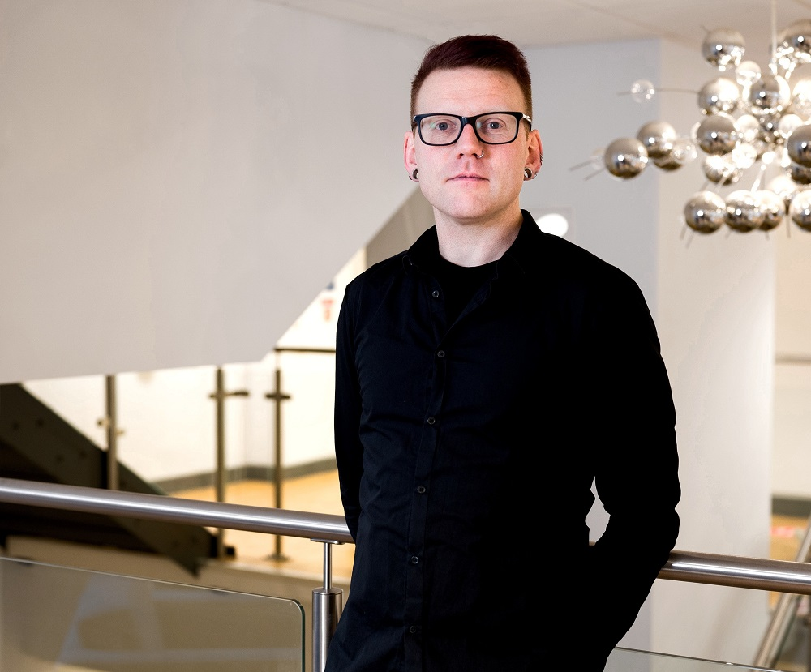

## About us: Thom Baguley

- Professor of Experimental Psychology
- Lectures on modeling discrete outcomes (e.g., binary and count data)
- Modeling data from a wide range of areas including cognitive, forensic and occupational data
- *Serious Stats: A guide to advanced statistics for the behavioral sciences* (Baguley 2012)

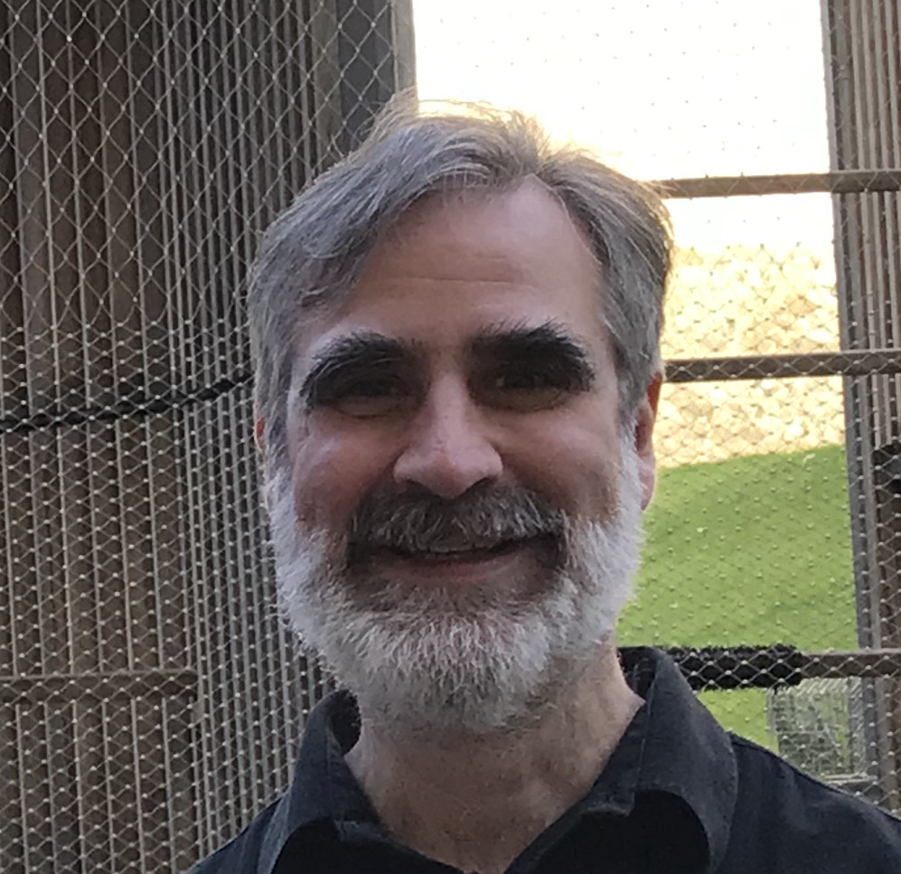

## About us: Mark Andrews

- Associate Professor in Statistical Methods
- ML for Statistics III
- Cognitive psychology
- Bayesian statistical and computational models
- UG Statistics II / III, MSc Advanced Stats
- *Doing Data Science in R: An Introduction for Social Scientists* (Andrews 2021); `psyntur` (Andrews and Roeser 2021)

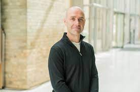

## Who are you?

> Say hi to everyone on your table and brainstorm …
- Which statistical tests do you remember and when do you use them?
- Wouldn’t it be nice to have one approach that can capture most (all?) of our data problems?

## Module Aims

- Provide a unified set of advanced statistical techniques that covers a wider range of data-analysis problems: multilevel generalised linear models
- General framework encapsulating a range of widely used techniques including linear regression, ANOVA, ANCOVA, MANCOVA, logistic regression, Poisson regression, log-linear, random effects / mixed-effects models etc.
- These models arise as special cases of a single underlying general principle.
- Apply this general principle to a wider range of data analysis problems.

## Module Aims

- **Multilevel generalised linear models** will be introduce as sequence of consecutively more general models, all of which build on linear regression.
- **Linear regression**: review of multiple linear regression and factorial ANOVA.
- **General linear models**: certain problems, which are poorly handled by ANOVA, can be easily accommodated (e.g. varying slope models).
- **Generalised linear models**: transformations applied to linear models allows modelling of data-types including categorical, ordinal, discrete frequency data.
- **Multi-level models**: data with inherently hierarchical structure, which have often been inadequately dealt with.

## Learning outcomes

> By the end of this module, you should be able to:
1. Apply advanced statistics to real-world data-analysis problems.
2. Use rational and principled arguments to justify the choice of statistical methods.
3. Engage in peer-to-peer debate about methods and practices of data-analysis.
4. Demonstrate a range of transferable skills, including data-analysis, data-preparation, computer programming, graphical presentation of quantitative evidence, reporting of data-analysis results.

## Why was it a good idea to choose this module?

- Why did you choose *Statistics III*?
- What do you expect to get out off this module?
- How confident do you feel about RStudio; how about stats?
- Is there anything you’re worried about with this module?

## Why was it a good idea to choose this module?

- Career opportunities! Stats and statistical software skills transfer to many different areas in academia and industry.
- You will be able to show-off your data analysis skill in your final year project, unless you are using qualitative methods.
- Solid understanding of statistical methods is relevant for planning data collections and making sense of quantitative data.
- Data analysis can be efficient, flexible, reliable, and fast once you have had enough R practice.
- You have the opportunity to improve your data analysis and R skills with three experts.

## Outline

Each week of Term 1, except PACE week. Each week one 4-hours workshop.

| Topic | Lecturer |
| --- | --- |
| Week 1: Introduction to module, and introduction to RMarkdown | Jens Roeser |
| Week 2: Normal linear models | Jens Roeser |
| Week 3: Model comparison | Jens Roeser |
| Week 4: Logistic regression | Thom Baguley |
| Week 5: Poisson regression | Thom Baguley |
| Week 6: PACE week |  |
| Week 7: Negative binomial and zero-inflated count models | Thom Baguley |
| Week 8: Multilevel linear models (I) | Mark Andrews |
| Week 9: Multilevel linear models (II) | Mark Andrews |
| Week 10: Revision (and loose ends) | Mark Andrews |

## Engaging with this module

- 1 \(\times\) 4-hours workshop each week.
- Mixture of theory and practical exercises.
- Together, we will work through statistics problems using R.
- For each topic, there will be detail accompanying lecture notes.
- To engage successfully with this module, attend all workshops, and read the lecture notes.
- For *excellent* results, you will need to demonstrate independent learning that goes beyond what we cover in class.

## Assessment

> **Using data-sets of your own choice, perform and report analyses using the tools in 1 – 4 to address a set of theoretical questions to address a research question of relevance to psychology.**
1. Logistic regression for binomial data
2. Regression models for count data
3. Multilevel regression models
4. A new methods that was not explicitly covered in class

## Assessment

*Psychological relevance*: address some non-trivial question of some psychological relevance using your chosen data.

- Very wide range of topics and sub-fields, many of which overlap with many other disciplines.
- Consider the data-set described [here](https://vincentarelbundock.github.io/Rdatasets/doc/AER/ResumeNames.html) published in

Bertrand, M. and Mullainathan, S. (2004). Are Emily and Greg More Employable Than Lakisha and Jamal? A Field Experiment on Labor Market Discrimination. *American Economic Review*, 94, 991–1013.

- Published in an economics journal but it addresses implicit racial bias, and is obviously related to psychology.

## Assessment

- Choose a different data set per each question.
- 4 separate data analyses reported on no more than 4 pages each.
- For all questions, provide full technical details, and graphical analysis.
- Theoretical model (assumed data-generative process) needs to be motivated.

## Assessment

- Deadline for submission via Dropbox: **Jan 13th 2025**
- Individual written feedback (by Feb 3rd 2025) to help you how to best carry out and report statistical analyses.
- We are looking for evidence of
  - understanding and knowledge of the theoretical basis.
  - how and why to apply certain statistical models.
  - practical skills in data manipulation and analysis.
- For high or exceptional grades, display learning that goes beyond the content explicitly taught in class.
- See [Grading Matrix](https://now.ntu.ac.uk/d2l/le/content/1038633/viewContent/13153112/View) on NOW for details.

## Assessment

- Work must be submitted as *single* zip archive with
  - One RMarkdown file
  - PDF document generated from RMarkdown
  - RStudio project file
  - Data and supplementary files (e.g. bibliography, custom R function)
  - For an example see [demo on NOW](https://now.ntu.ac.uk/d2l/le/content/961441/viewContent/12102010/View).
- Work must be reproducible using RMarkdown file.
- Your analysis, plots, descriptions, for each question will be contained in RMarkdown file, and this will reference all relevant data files.

## Assessment

- Where do I find data sets:
  - Journals such as [Journal of Open Psychology Data](https://openpsychologydata.metajnl.com/), [Nature: Scientific data](https://www.nature.com/sdata/), [Bahavior Research Methods](https://www.springer.com/journal/13428), [PLOS](https://plos.org/open-science/open-data/), [Psychonomic Bulletin & Review](https://www.springer.com/journal/13423?gclid=CjwKCAjwsKqoBhBPEiwALrrqiL8B1Z2FsdJl_yJq2CJaj1_bm4QuFOHx6Pjjs_SixnEA-QgAdiPemxoCnW4QAvD_BwE)
  - [ONS](https://www.ons.gov.uk/)
  - [R data sets](http://vincentarelbundock.github.io/Rdatasets/datasets.html)
  - [OSF](https://osf.io/), [GitHub](https://github.com/), [figshare](https://figshare.com/)
- Pick a topic that has psychological relevance (maybe related to your final project).
- Only restriction: no confidential data.

## Assessment

> For all tasks, provide …
- descriptive statistics and graphical visualizations of the data.
- full details of the statistical model that you are using (multiple predictors incl. categorical predictors, interaction terms).
- full statistical details of model fit and comparisons with alternative models.
- full statistical details of the inferred model parameter value estimates.
- analysis, including graphical analysis, of the predictions of the model (model checks).

## Question 4: A new topic

- Y3 modules require you to go beyond the class contents.
- Look for text books and online tutorials, e.g. [my tutorial for mixture models](https://rpubs.com/jensroes/mixture-models-tutorial).
- Examples: time series, structural equation modelling (SEM), auto-regression models, non-linear regression, signal detection theory, mixture models, categorical models, multi-nomial models, multi-variate models, diffusion models, Bayesian models …
- Talk to your supervisor / us re advanced analyses relevant for your project.

## Formative assessment

- Practice how to write a the kind of report we expect from you.
- Data-analysis report using linear regression to address a psychologically relevant question.
- Support in workshops.
- Just one data analysis hence 4 pages max.
- Submit single zip archive via Dropbox until end October (deadline tba).
- Feedback on what you did well and what you can improve.
- It does not (directly) affect your grade.

## Task

- Have a look at the [Grading Matrix](https://now.ntu.ac.uk/d2l/le/content/961441/viewContent/12100887/View) on NOW.
- Is there anything you find unclear?
- What concerns have you got with the task?
- What opportunities do you see? Have you got ideas you want to share?

## Support

- MS Teams channel for R, stats, assessment-related questions, and useful resources.
- Because our answers will be of interest to everyone / easy code sharing, tagging.
- Also you will receive an answer faster.
- We might refer emails to the forum so everyone can benefit from our answer.
- Help each other!
- Online support will stop at **Dec 20 2024**.
- For confidential questions contact ML Mark Andrews: `mark.andrews@ntu.ac.uk`

## Tech requirements

- You need R and RStudio on your own machine: [instructions](https://posit.co/download/rstudio-desktop/)
- Don’t rely on RStudio Cloud or university machines.
- Check if `tidyverse` is installed.
- If not run

```r
install.packages("tidyverse")
```

## Required and recommended reading

- See weekly lecture notes on NOW.
- Also Mark’s book published [here](https://us.sagepub.com/en-us/nam/author/mark-andrews) (Andrews 2021) with data sets and R code available here [here](https://www.mjandrews.org/book/ddsr).
- [“R for Data Science”](https://r4ds.had.co.nz/) by Wickham and Grolemund for data wrangling, visualisation and modelling (Wickham and Grolemund 2016).
- Advanced regression analysis: [“Regression and other Stories”](https://avehtari.github.io/ROS-Examples/) by Gelman, Hill, and Vehtari (2020).

[figure not shown]

[figure not shown]

## What questions have you got?

- How will the module be taught?
- What’s the assessment like?
- How will you be supported?
- What’s expected of you?

## References

Andrews, Mark. 2021. *Doing Data Science in R: An Introduction for Social Scientists*. SAGE Publications Ltd.

Andrews, Mark, and Jens Roeser. 2021. *psyntur: Helper Tools for Teaching Statistical Data Analysis*. https://CRAN.R-project.org/package=psyntur.

Baguley, Thom. 2012. *Serious Stats: A Guide to Advanced Statistics for the Behavioral Sciences*. Macmillan International Higher Education.

Garcia, Rowena, Jens Roeser, and Evan Kidd. 2023. “Finding Your Voice: Voice-Specific Effects in Tagalog Reveal the Limits of Word Order Priming.” *Cognition* 236: 105424.

Gelman, Andrew, Jennifer Hill, and Aki Vehtari. 2020. *Regression and Other Stories*. Cambridge University Press.

Roeser, Jens, Sven De Maeyer, Mariëlle Leijten, and Luuk Van Waes. 2021. “Modelling Typing Disfluencies as Finite Mixture Process.” *Reading and Writing*, 1–26.

Roeser, Jens, Mark Torrance, and Thom Baguley. 2019. “Advance Planning in Written and Spoken Sentence Production.” *Journal of Experimental Psychology: Learning, Memory, and Cognition* 45 (11): 1983–2009.

Wickham, Hadley, and Garrett Grolemund. 2016. *R for Data Science: Import, Tidy, Transform, Visualize, and Model Data*. O’Reilly Media, Inc.